# Module 3 — Single-Species Occupancy

Snapshot Brasil multi-network camera-trap pipeline

**What this module covers**

Two different covariate sets are used, chosen in Module 2: an **11-covariate camera-level set** (forest, savanna, pasture, cropland, landscape-scale native vegetation, temperature, precipitation, built-surface extent, distance to road, distance to water, plus protected-area status) for models fit at the camera level, and a leaner **6-covariate array-level set** (a data-driven reduction of the same candidates) for the one place in this module where the sampling unit is collapsed to the array. Every species-level model uses the range-mask candidate site set from Module 2’s range-map evaluation: sites outside a species’ mapped range that were never detected there are excluded by default; sites detected outside the mapped range are always kept.

```r
ds <- fread(file.path(DATA, "dataset_summary.csv"))
```

# 1 A first occupancy model: Nine-banded Armadillo

We start with the **Nine-banded Armadillo** (*Dasypus novemcinctus*), a well-detected species, and fit a model using every covariate in the 11-covariate camera-level set: forest, savanna, pasture, cropland, landscape-scale native vegetation, temperature, precipitation, built-surface extent, distance to road, distance to water, and protected-area status.

```r
arm_n <- fread(file.path(DATA, "armadillo_candidate_sites.csv"))
```

## 1.1 Detection history

Occupancy models are built from a **detection history**: for each 7-day occasion, was the species detected (1), not detected (0), or was the camera not running (missing)? The picture below shows two contrasting arrays: one with many detections, one with almost none.

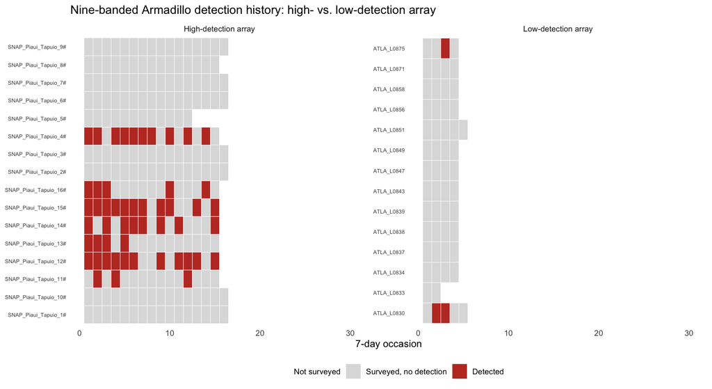

Armadillo detection history at two named arrays: SNAP_Piaui_Caatinga_Tapuio_25 (high detection rate) and ATLA_ATL_11 (almost no detections). The same species, two very different local pictures.

```r
knitr::include_graphics(file.path(FIGS, "m3_dethist_armadillo.png"))
```

## 1.2 Fitting the model, with the array random effect

We fit the model with a random intercept per array — the pipeline’s standard correction for pseudoreplication among cameras that share the same array (see Module 2). Because this is a *random*-effects model, we use a Bayesian engine (`spOccupancy::PGOcc`) rather than the maximum-likelihood `unmarked` package, which only fits fixed effects.

```r
pg <- fread(file.path(DATA, "armadillo_pgocc_coefs.csv"))
knitr::kable(pg[param != "(Intercept)"], digits=3,
  caption="Nine-banded Armadillo occupancy model, array random effect included, 11-covariate camera-level set (posterior mean, and 95% credible interval).")
```

Nine-banded Armadillo occupancy model, array random effect included, 11-covariate camera-level set (posterior mean, and 95% credible interval).

| param | mean | ci_lo | ci_hi |
| --- | --- | --- | --- |
| forest_100m_z | 0.955 | 0.409 | 1.514 |
| savanna_100m_z | 0.469 | -0.243 | 1.129 |
| pasture_100m_z | 0.017 | -0.334 | 0.354 |
| cropland_100m_z | 0.160 | -0.142 | 0.474 |
| native_veg_1000m_z | -0.342 | -0.734 | 0.051 |
| temp_mean_C_z | 0.167 | -0.555 | 0.884 |
| precip_annual_mm_z | 0.162 | -0.748 | 0.981 |
| ghsl_built_5000m_z | 0.345 | -0.034 | 0.981 |
| dist_road_m_z | -0.288 | -1.064 | 0.437 |
| dist_water_m_z | 0.356 | -0.072 | 0.816 |
| in_pa | -1.230 | -2.163 | -0.327 |

## 1.3 Naive vs. modeled occupancy

“Naive occupancy” is simply the fraction of sites where the species was ever detected — it always *underestimates* true occupancy, because a species can be present but missed on every visit.

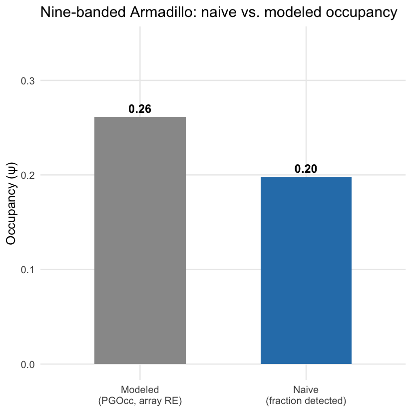

Naive occupancy undercounts the model-based estimate, as expected — some armadillos went undetected at every occasion.

```r
knitr::include_graphics(file.path(FIGS, "m3_naive_vs_modeled.png"))
```

## 1.4 Covariate effects

The panel below shows predicted occupancy against the covariate with a credible effect in the array random-effect fit, holding the others at their mean.

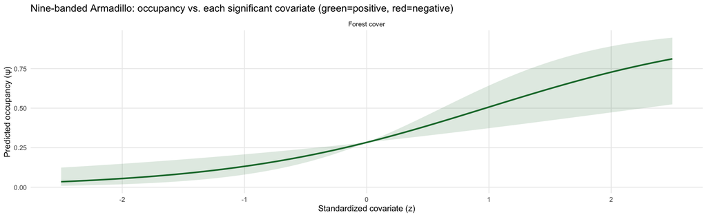

Nine-banded Armadillo occupancy as a function of the significant covariate, with 95% credible band (array-RE model). Occupancy rises with forest cover. Green = positive effect.

```r
knitr::include_graphics(file.path(FIGS, "m3_armadillo_effect_curves.png"))
```

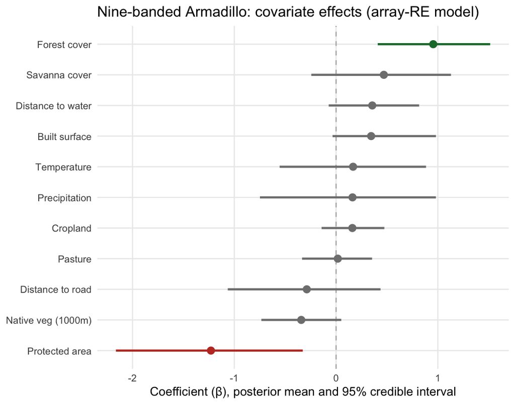

Nine-banded Armadillo: every covariate effect in the array random-effect model, with 95% credible intervals. Green = credible interval excludes zero and is positive, red = credible interval excludes zero and is negative, grey = not distinguishable from zero.

```r
knitr::include_graphics(file.path(FIGS, "m3_armadillo_beta_ci.png"))
```

## 1.5 Model fit: what do these numbers actually mean?

Two very different questions get asked of a fitted occupancy model:

- **Does the model discriminate** occupied sites from unoccupied ones? — AUC. Take the model’s predicted occupancy probability at every site and ask: if you picked one truly-occupied site and one truly-unoccupied site at random, how often would the model give the occupied one a higher predicted probability? AUC = 0.5 is chance; AUC = 1.0 is perfect.
- **Is the assumed error structure correct?** — c-hat (overdispersion), from a parametric-bootstrap goodness-of-fit test. c-hat near 1 means the assumed binomial detection process fits; notably above 1 means real detections are more variable than the model expects. AUC and c-hat are **not** interchangeable — a model can discriminate well (high AUC) and still be overdispersed.

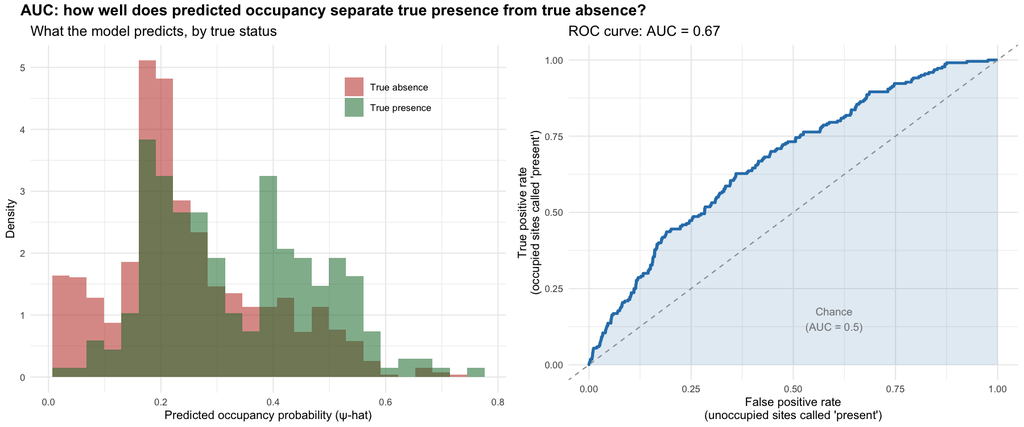

Left: the model’s predicted occupancy probability, split by whether the species was actually detected at that site. Right: the ROC curve this comparison implies, with the resulting AUC.

```r
knitr::include_graphics(file.path(FIGS, "m3_auc_explainer.png"))
```

```r
fs <- fread(file.path(DATA, "armadillo_fit_summary.csv"))
knitr::kable(fs, digits=3, col.names=c("AUC","c-hat","Bootstrap GoF p-value","Detection probability"),
  caption="Model-fit diagnostics for the Nine-banded Armadillo array-RE fit.")
```

Model-fit diagnostics for the Nine-banded Armadillo array-RE fit.

| AUC | c-hat | Bootstrap GoF p-value | Detection probability |
| --- | --- | --- | --- |
| 0.672 | 1.609 | 0 | 0.193 |

An AUC around 0.65 indicates modest discrimination — better than chance, but far from perfect, which is typical for occupancy models built on binary detection data. A c-hat above 1 means the model is overdispersed relative to the assumed binomial detection process — both common, expected findings, not a sign the model is unusable.

## 1.6 Does adding protected-area status improve the model?

```r
pa <- fread(file.path(DATA, "armadillo_pa_effect.csv"))
knitr::kable(pa, digits=3, col.names=c("\u0394AIC","Direction","\u03c8 outside PA","\u03c8 inside PA","Ratio (in / out)"),
  caption="AIC improvement from adding protected-area status, and predicted occupancy inside vs. outside protected areas, other covariates held at their mean.")
```

AIC improvement from adding protected-area status, and predicted occupancy inside vs. outside protected areas, other covariates held at their mean.

| ΔAIC | Direction | ψ outside PA | ψ inside PA | Ratio (in / out) |
| --- | --- | --- | --- | --- |
| 21.8 | negative | 0.369 | 0.183 | 0.5 |

Adding `in_pa` produces a decisive AIC improvement. The direction of the effect is **negative**: Armadillo occupancy is lower inside protected areas. In concrete terms, predicted occupancy inside protected areas is roughly half of predicted occupancy outside — a substantial effect, not just a statistically detectable one.

# 2 Every species, together

We go straight to the array random-effect model for the community fit — a fixed-effects-only engine is unreliable for roughly half the community (quasi-complete separation, standard errors well above 5, usually because one land-cover class is close to zero at nearly every detection site).

```r
cfc <- fread(file.path(DATA, "community_fit_count.csv"))
```

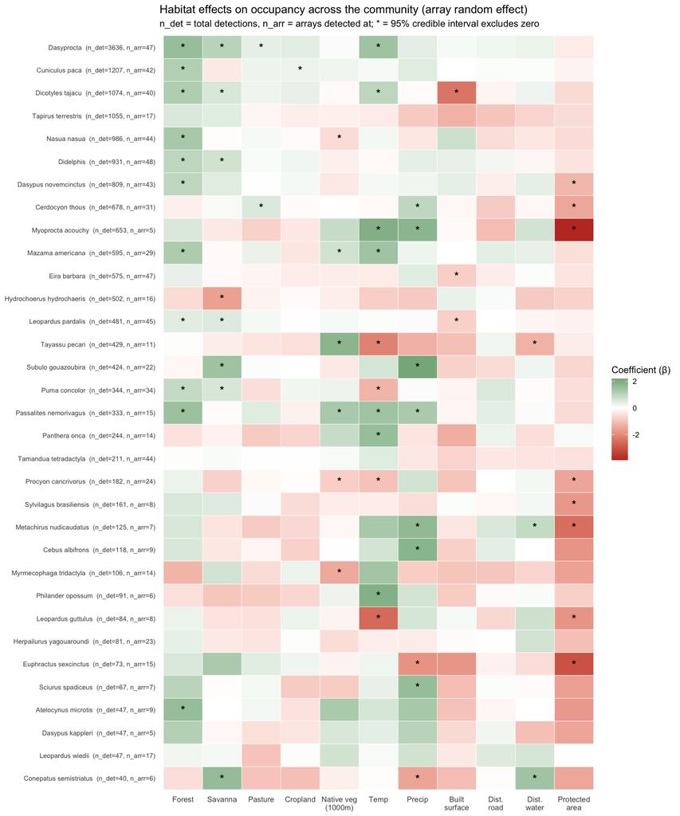

Habitat effects on occupancy across the community, array random effect included, 11-covariate camera-level set. n_det = total detections, n_arr = arrays with a detection. A star marks a 95% credible interval that excludes zero. Green = positive, red = negative.

```r
knitr::include_graphics(file.path(FIGS, "m3_beta_shaded_table.png"))
```

Forest is the most consistently important covariate across the community, positive for the great majority of species with a credible effect.

## 2.1 Does the array-level simplification hold?

Module 2 flagged that habitat is not always homogeneous within an array. We test directly: does using arrays — rather than individual cameras — as the sampling unit change the ecological conclusions? This is now a comparison of **two genuinely different covariate sets**, not just two sampling levels with the same covariates: the camera-level fit uses the full 11-covariate set (1,110+ sites easily supports this); the array-level fit uses the reduced 6-covariate set (60 arrays cannot support more; see Module 2 for how that set was chosen).

Six species illustrate the comparison: Spotted Paca and Nine-banded Armadillo (data-rich), White-lipped Peccary (sparser, range-masked), and Ocelot, Lowland Tapir, and Puma (chosen for large camera-vs-array shifts).

```r
ac <- fread(file.path(DATA, "array_completeness.csv"))
```

60 of 61 arrays have complete covariate data for array-level models — one array has no valid camera-level habitat data on any of its cameras and is dropped rather than silently carried as an undefined average.

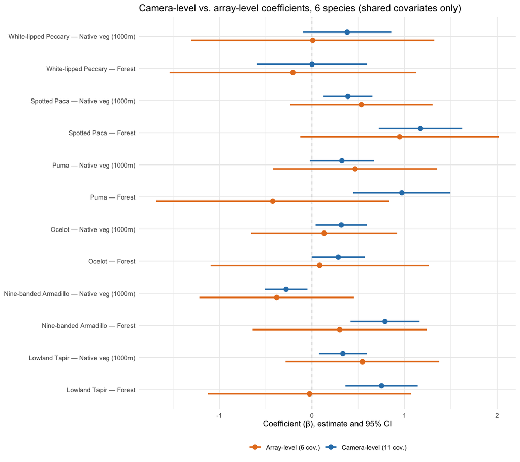

Camera-level (11 covariates) vs. array-level (6 covariates) occupancy coefficients and 95% confidence intervals, for the same six species, restricted to the two covariates both models share (forest and landscape-scale native vegetation). Confidence intervals widen sharply at the array level — fewer sampling units means less power.

```r
knitr::include_graphics(file.path(FIGS, "m3_array_vs_site_6species.png"))
```

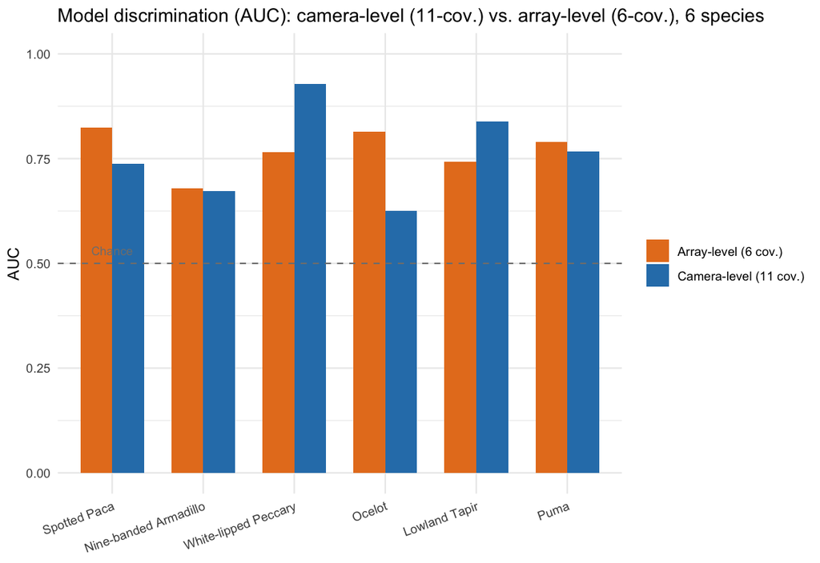

Model discrimination (AUC) at the camera level (11 covariates) vs. the array level (6 covariates), for the same six species. Array-level AUC is typically higher — fewer, cleaner sampling units are easier to discriminate, at the cost of much wider confidence intervals.

```r
knitr::include_graphics(file.path(FIGS, "m3_camera_vs_array_fit_6species.png"))
```

```r
fst <- fread(file.path(DATA, "fitstats_6species.csv"))
common_lookup6 <- c("Cuniculus paca"="Spotted Paca","Dasypus novemcinctus"="Nine-banded Armadillo",
                    "Tayassu pecari"="White-lipped Peccary","Leopardus pardalis"="Ocelot",
                    "Tapirus terrestris"="Lowland Tapir","Puma concolor"="Puma")
fst[, common := common_lookup6[species]]
knitr::kable(fst[, .(common, n_site, n_array, auc_site, auc_array)], digits=3,
  col.names=c("Species","N (camera-level)","N (array-level)","AUC (camera, 11 cov.)","AUC (array, 6 cov.)"),
  caption="Camera-level vs. array-level model-fit statistics, six species.")
```

Camera-level vs. array-level model-fit statistics, six species.

| Species | N (camera-level) | N (array-level) | AUC (camera, 11 cov.) | AUC (array, 6 cov.) |
| --- | --- | --- | --- | --- |
| Spotted Paca | 1110 | 60 | 0.737 | 0.824 |
| Nine-banded Armadillo | 1110 | 60 | 0.672 | 0.679 |
| White-lipped Peccary | 838 | 44 | 0.929 | 0.766 |
| Ocelot | 1110 | 60 | 0.625 | 0.815 |
| Lowland Tapir | 1007 | 53 | 0.839 | 0.743 |
| Puma | 1110 | 60 | 0.767 | 0.790 |

Note that the camera-level model also carries four covariates — built-surface extent, distance to road, distance to water, protected-area status — that the array-level model has no room to include; the coefficient comparison above is restricted to the two covariates both models share.

## 2.2 Why this comparison matters

This reflects a pipeline design choice: use the array as the primary replication unit for community/joint models (Module 4+), while fitting single-species models at the finer camera level here. Point estimates generally keep a consistent sign between levels for well-detected species, but the array-level result for a sparse or heavily range-masked species should be treated as a much weaker signal than its p-value alone suggests.

There is also a more general ecological framework for why camera-level and array-level results can legitimately differ, not just statistically but biologically: **Johnson’s (1980) hierarchy of habitat selection**. Johnson observed that animals select habitat at nested spatial scales — from the geographic range down to the individual resource item — and that a habitat association measured at one scale doesn’t automatically transfer to another. An **array-level** occupancy model asks a **second-order** question: what determines *where*, across the broader landscape, a home range (here approximated by the array footprint) ends up detecting the species at all? A **camera-level** model asks a **third-order** question: given that a home range is already present, what fine-scale microhabitat features predict detection at *this specific spot* within it? These are genuinely different questions, and a covariate can matter at one order and not the other simply because it operates at a different spatial scale than the one being tested.

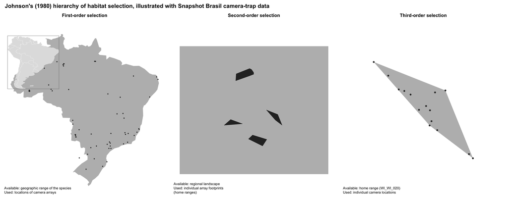

Johnson’s (1980) hierarchy of habitat selection, illustrated with real Snapshot Brasil array coordinates. First-order selection: the species’ geographic range vs. where camera arrays are placed within it. Second-order selection: a regional landscape vs. the home-range footprints of four nearby arrays. Third-order selection: a single array’s home range vs. the individual camera locations within it — the two orders (second and third) this module’s camera-vs-array comparison directly models.

```r
knitr::include_graphics(file.path(FIGS, "m3_johnson_levels_of_selection.png"))
```

## 2.3 Species groupings from the coefficient table

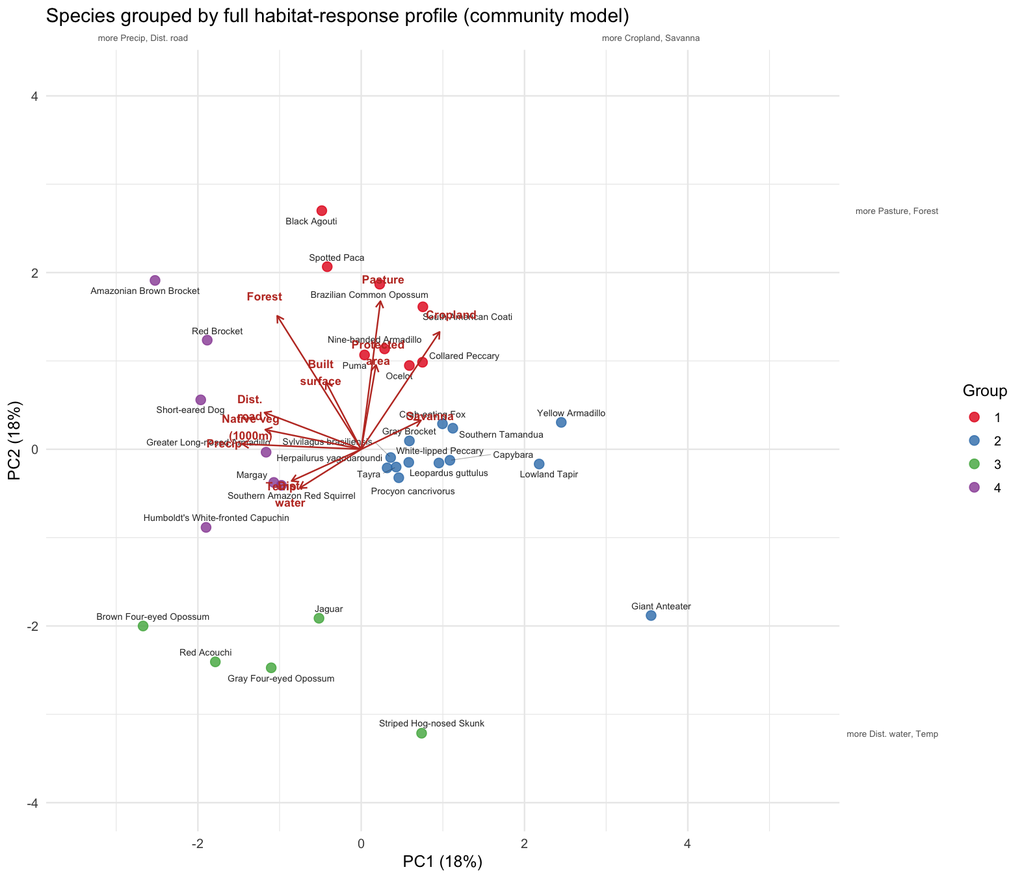

```r
knitr::include_graphics(file.path(FIGS, "m3_species_pca_biplot.png"))
```

# 3 Adding an interaction effect

We extend the occupancy model to let one habitat effect depend on another variable — here, whether the effect of tree cover on occupancy changes with temperature. This is fit as a **full model**, not an interaction term alone:

```
psi ~ tree_cover * temperature + savanna + pasture + cropland +
      native_veg_1000m + precipitation + built_surface_5000m +
      dist_road + dist_water + in_pa
```

Tree cover (a MapBiomas year-2000 baseline layer, distinct from the pipeline’s standard `forest_100m` covariate) substitutes for forest in this model, since the two are highly correlated (r = 0.82) and would otherwise create collinearity with the interaction term. All other covariates from the 11-covariate camera-level set remain in the model as ordinary additive effects.

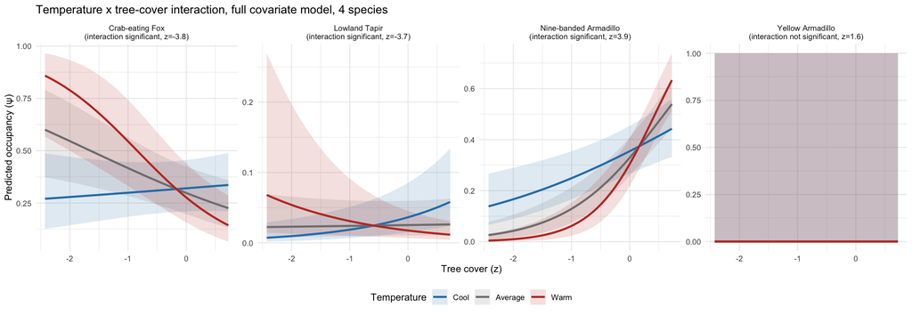

Temperature x tree-cover interaction, full model (all other covariates included and held at their mean), with 95% confidence bands. Cool (blue), average (grey), and warm (red) temperature scenarios are plotted separately.

```r
knitr::include_graphics(file.path(FIGS, "m3_interaction_4species.png"))
```

```r
i4 <- fread(file.path(DATA, "interaction_4species.csv"))
knitr::kable(i4[, .(common, interaction_coef, z)], digits=3,
  col.names=c("Species","Interaction coefficient","z"),
  caption="Temperature x tree-cover interaction term, full model, four species.")
```

Temperature x tree-cover interaction term, full model, four species.

| Species | Interaction coefficient | z |
| --- | --- | --- |
| Lowland Tapir | -0.632 | -3.66 |
| Yellow Armadillo | 17.804 | 1.63 |
| Nine-banded Armadillo | 0.693 | 3.86 |
| Crab-eating Fox | -0.620 | -3.84 |

An interaction term is a useful extension when a single slope genuinely doesn’t capture the ecology — here, three of four species show a genuine, statistically supported tree-cover-by-temperature interaction even after controlling for the full covariate set, which an additive-only model would average away.

## 3.1 Does this interaction cluster by taxonomic order?

The four-species example above shows the interaction can matter a great deal for a handful of species. We extend this to the full community: fit the *same* interaction to every modeled species/genus, tag each by taxonomic order, and ask whether any order stands out — specifically, whether **Xenarthra** (armadillos, anteaters; thermal physiology closer to ectothermy than other placental mammals) shows a more pronounced temperature-dependence in its forest-use response than the rest of the community.

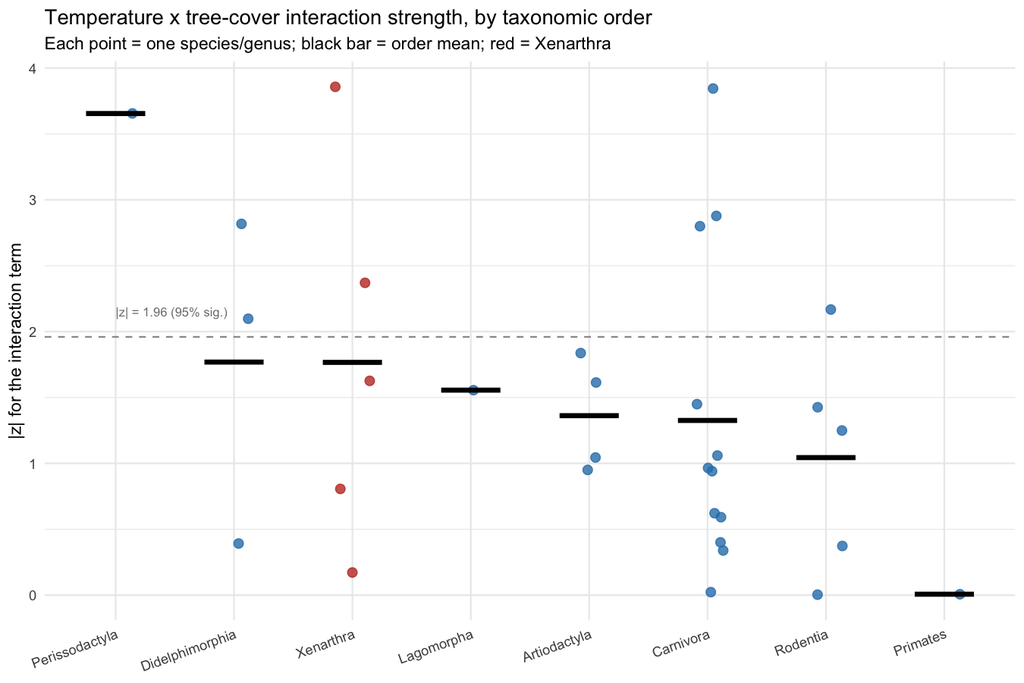

Temperature x tree-cover interaction strength (|z|), by taxonomic order. Each point is one species/genus; the black bar is the order mean; red points are Xenarthra.

```r
knitr::include_graphics(file.path(FIGS, "m3_interaction_by_order.png"))
```

```r
osum <- fread(file.path(DATA, "order_interaction_summary.csv"))
knitr::kable(osum, digits=2, col.names=c("Order","N species","Mean |z|","Median |z|","% significant"),
  caption="Temperature x tree-cover interaction strength, by taxonomic order.")
```

Temperature x tree-cover interaction strength, by taxonomic order.

| Order | N species | Mean \|z\| | Median \|z\| | % significant |
| --- | --- | --- | --- | --- |
| Perissodactyla | 1 | 3.66 | 3.66 | 100.00 |
| Didelphimorphia | 3 | 1.77 | 2.10 | 66.67 |
| Xenarthra | 5 | 1.77 | 1.63 | 40.00 |
| Lagomorpha | 1 | 1.56 | 1.56 | 0.00 |
| Artiodactyla | 4 | 1.36 | 1.33 | 0.00 |
| Carnivora | 12 | 1.33 | 0.95 | 25.00 |
| Rodentia | 5 | 1.04 | 1.25 | 20.00 |
| Primates | 1 | 0.01 | 0.01 | 0.00 |

```r
xt <- fread(file.path(DATA, "xenarthra_test.csv"))
```

Xenarthra’s mean |z| (1.77, n = 5) is somewhat higher than the rest of the community combined (1.37, n = 27), but a Wilcoxon rank-sum test finds no significant difference (p = 0.5448). With only 5 Xenarthra species in the modeled set, this test has limited power — the pattern is suggestive, not conclusive, and is a useful example for students of a hypothesis that is easy to state but hard to test cleanly with this sample size.

A single |z| number per species compresses away the *shape* of each interaction — two species can both have a large |z| while one shows a narrowing gap between cool and warm scenarios and the other shows a crossover. To compare shapes directly rather than just magnitudes, we plot the fitted cool-vs-warm prediction curves for the ten species/genera with the strongest interaction, all on a common scale:

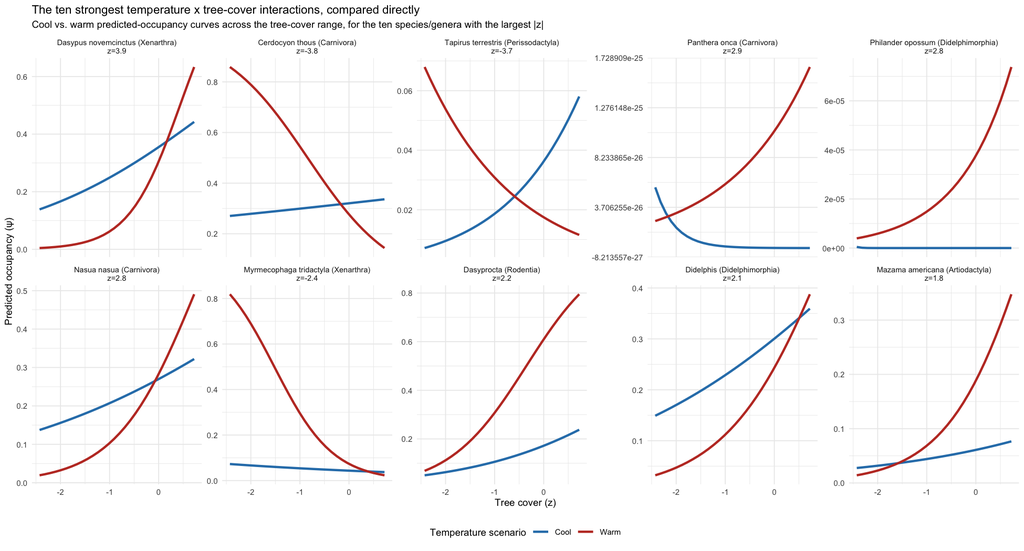

The ten strongest temperature x tree-cover interactions, compared directly by their fitted cool-vs-warm prediction curves rather than by |z| alone. Each panel is one species/genus, ordered by interaction strength; the taxonomic order and z-value are given in each panel’s label.

```r
knitr::include_graphics(file.path(FIGS, "m3_interaction_top10.png"))
```

```r
top10 <- fread(file.path(DATA, "top10_interaction_species.csv"))
knitr::kable(top10, digits=2, col.names=c("Species/genus","Interaction z","Taxonomic order"),
  caption="The ten species/genera with the strongest temperature x tree-cover interaction, ranked by |z|.")
```

The ten species/genera with the strongest temperature x tree-cover interaction, ranked by |z|.

| Species/genus | Interaction z | Taxonomic order |
| --- | --- | --- |
| Dasypus novemcinctus | 3.86 | Xenarthra |
| Cerdocyon thous | -3.84 | Carnivora |
| Tapirus terrestris | -3.66 | Perissodactyla |
| Panthera onca | 2.88 | Carnivora |
| Philander opossum | 2.82 | Didelphimorphia |
| Nasua nasua | 2.80 | Carnivora |
| Myrmecophaga tridactyla | -2.37 | Xenarthra |
| Dasyprocta | 2.17 | Rodentia |
| Didelphis | 2.10 | Didelphimorphia |
| Mazama americana | 1.84 | Artiodactyla |

# 4 Letting a relationship vary by ecoregion

A different way habitat relationships can vary: not with a continuous covariate, but across ecologically distinct regions. We test this with **Ocelot**, comparing a single pooled forest effect against a **full model** that lets the forest effect differ between two ecoregions with enough data (at least six arrays each) — Moist Broadleaf Forest and the drier Grasslands/Savannas & Shrublands — while every other covariate stays in the model as an ordinary additive (fixed, not ecoregion-varying) effect:

```
psi ~ forest * ecoregion + savanna + pasture + cropland +
      native_veg_1000m + temperature + precipitation +
      built_surface_5000m + dist_road + dist_water + in_pa
```

```r
eco <- fread(file.path(DATA, "ecoregion_ocelot_aic.csv"))
knitr::kable(eco, digits=1, col.names=c("\u0394AIC (interaction model favored)"),
  caption="AIC comparison: pooled forest effect vs. ecoregion-interaction model, full covariate set.")
```

AIC comparison: pooled forest effect vs. ecoregion-interaction model, full covariate set.

| ΔAIC (interaction model favored) |
| --- |
| 6.6 |

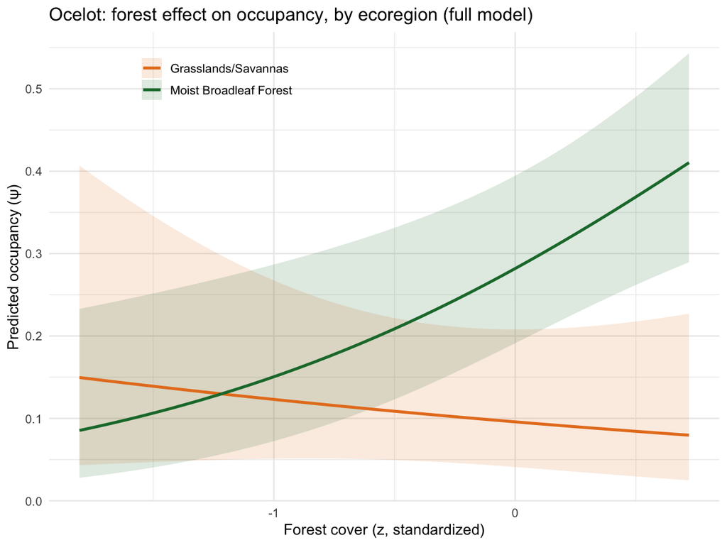

Ocelot occupancy as a function of forest cover, fit separately by ecoregion (full model, other covariates fixed at their mean), with 95% confidence bands. In Moist Broadleaf Forest, more forest cover means more Ocelot occupancy. In Grasslands/Savannas & Shrublands the relationship reverses direction.

```r
knitr::include_graphics(file.path(FIGS, "m3_ecoregion_ocelot.png"))
```

This is the same lesson as the temperature interaction, applied to a categorical rather than continuous moderator: a single “forest effect” number can hide two genuinely different relationships that only become visible once the data are split by ecological context.

# 5 Comparing to Royle-Nichols abundance

The **Royle-Nichols model** uses the same 1/0 detection data as occupancy, but interprets the *frequency* of detection across occasions as a signal of how many individuals are present at a site, not just whether the species is present at all.

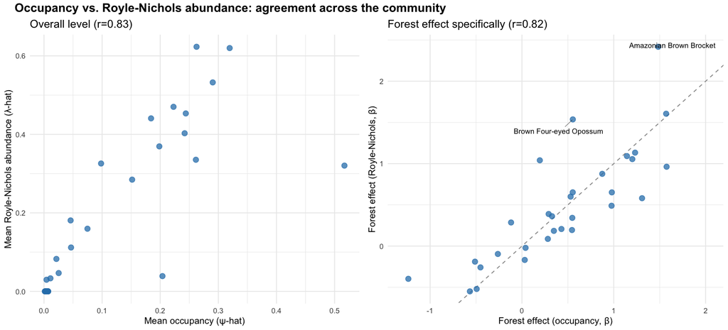

Left: mean occupancy (ψ-hat) vs. mean Royle-Nichols relative abundance (λ-hat) across the community. Right: forest effect estimated two ways — standard occupancy vs. Royle-Nichols abundance, with the two largest deviations from the 1:1 line labeled by common name. Unstable Royle-Nichols fits are excluded from both panels.

```r
knitr::include_graphics(file.path(FIGS, "m3_occ_vs_abundance.png"))
```

```r
rnc <- fread(file.path(DATA, "rn_vs_occ_correlation.csv"))
knitr::kable(rnc, digits=2, col.names=c("Overall-level r","Forest-effect r","N Royle-Nichols fit","N modeled"),
  caption="Agreement between occupancy and Royle-Nichols abundance across the community.")
```

Agreement between occupancy and Royle-Nichols abundance across the community.

| Overall-level r | Forest-effect r | N Royle-Nichols fit | N modeled |
| --- | --- | --- | --- |
| 0.83 | 0.82 | 33 | 33 |

Agreement is strong on overall level and solid on the forest effect specifically — a useful cross-check that the community model’s habitat signal is not an artifact of the occupancy framework’s binary detection assumption.

# 6 What the results mean

- Every model in this module uses the range-masked candidate site set from Module 2’s range-map evaluation, and the 11-covariate camera-level / 6-covariate array-level split decided in Module 2’s data-driven covariate ranking.
- Fixed-effects-only fitting is unreliable for roughly half the community due to separation; the array random-effect model resolves this by regularizing through the array intercept and is the pipeline’s default.
- Forest cover is the community’s most consistent habitat signal; occupancy and Royle-Nichols abundance agree well on both overall level and the forest effect specifically, once unstable Royle-Nichols fits are excluded.
- Collapsing cameras to arrays as the sampling unit — and the covariate set along with it — widens confidence intervals substantially, a real cost in statistical power, though point estimates mostly keep a consistent direction across the two levels.
- Two extensions — a continuous interaction (temperature x tree cover) and a categorical one (ecoregion) — both show that a single “one number fits all” habitat effect can obscure real, ecologically sensible variation, fit as full models with the complete covariate set rather than the interaction term alone.
- Testing the same temperature x tree-cover interaction across the whole community, grouped by taxonomic order, is a natural extension of the single-species interaction result — but with only five Xenarthra species in the modeled set, this is a sample-size-limited, suggestive test rather than a confirmed finding either way.
- Protected-area status is a genuinely large effect for Nine-banded Armadillo: predicted occupancy inside protected areas is roughly half of predicted occupancy outside, holding other covariates at their mean.